# Tie formation mechanisms in social networks

Network analysis; an introduction (with igraph in R)

Ali (Aliakbar Akbaritabar) Email: Akbaritabar@demogr.mpg.de 2019-11-21 - Humboldt-Universität zu Berlin Updated on: 2024-06-17 - MPIDR Summer Incubator Program

## Introduction to iGraph in R

The iGraph interface is very consistent between R, Python and I suppose in Mathematica and C.

## Outline of brief introduction to Network Analysis

> 1. What is relational view and network analysis?
> 2. Ethnography of network ties! Context of interactions
> 3. How to gather and use network data?
> 4. Possible questions to ask!
> 5. A real life example from science studies!
> 6. Where to next?!

## Read Edge List as CSV (to construct a network)

```r
library(tidyverse)
edge_list2_use <- read_csv("../data/humans_ties.csv")
# take a look
edge_list2_use
```

```
## # A tibble: 7 × 4
##   source   target   weight label
##   <chr>    <chr>     <dbl> <chr>
## 1 Tom      Sara        0.5 Acquaintance
## 2 Sara     Bill        1   Sibling
## 3 Sara     Margaret    0.5 Acquaintance
## 4 Bill     Tom         0.5 Acquaintance
## 5 Bill     Sara        1   Sibling
## 6 Bill     Margaret    1   Friend
## 7 Margaret Bill        0.5 Acquaintance
```

## Convert it to a (network) graph object[^1]

```r
library(igraph)
gg = graph_from_data_frame(d = edge_list2_use, directed = TRUE)

print(gg)
```

```
## IGRAPH 12cb289 DNW- 4 7 --
## + attr: name (v/c), weight (e/n), label (e/c)
## + edges from 12cb289 (vertex names):
## [1] Tom     ->Sara     Sara    ->Bill     Sara    ->Margaret Bill    ->Tom
## [5] Bill    ->Sara     Bill    ->Margaret Margaret->Bill
```

## Plot the graph with a layout (directed)

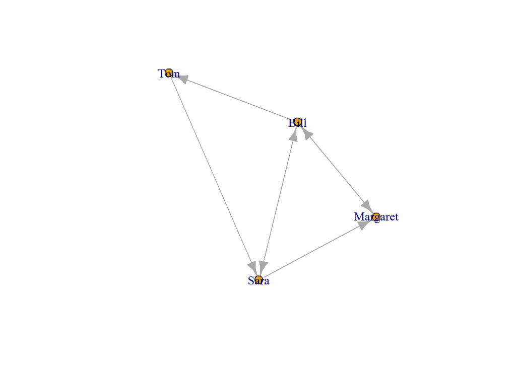

```r
set.seed(2225235)
gg_layout = layout.fruchterman.reingold(graph = gg)
plot(gg, layout = gg_layout, edge.label = NA, vertex.size=8)
```

## Plot the graph with a layout (un-directed)

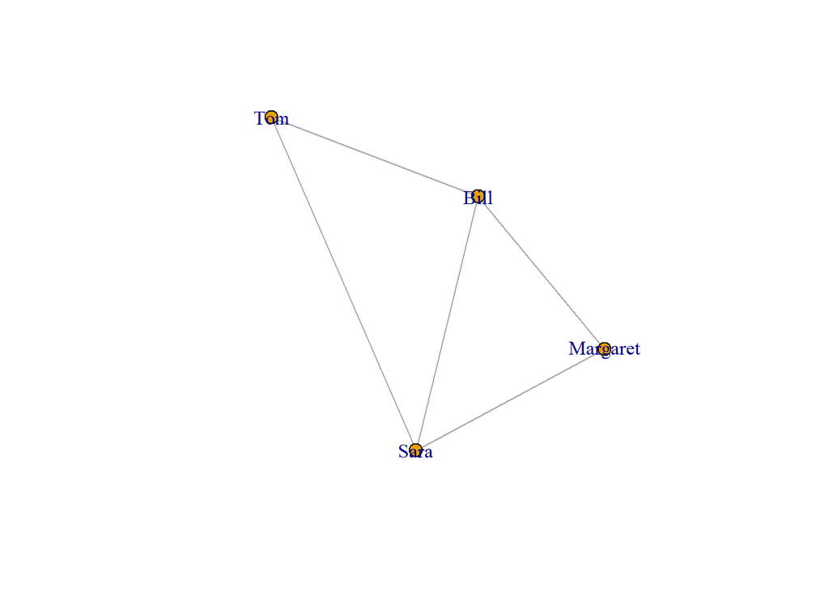

```r
gg_undirected = graph_from_data_frame(d = edge_list2_use, directed = F)
gg_undirected = simplify(graph = gg_undirected, remove.multiple = T)
plot(gg_undirected, layout = gg_layout, edge.label = NA, vertex.size=8)
```

## Add a new attribute to nodes?

```r
print(V(gg))
```

```
## + 4/4 vertices, named, from 12cb289:
## [1] Tom      Sara     Bill     Margaret
```

```r
V(gg)$gender <- c('male', 'female', 'male', 'female')
V(gg)$shape <- c('circle', 'square', 'circle', 'square')
print(gg)
```

```
## IGRAPH 12cb289 DNW- 4 7 --
## + attr: name (v/c), gender (v/c), shape (v/c), weight (e/n), label
## | (e/c)
## + edges from 12cb289 (vertex names):
## [1] Tom     ->Sara     Sara    ->Bill     Sara    ->Margaret Bill    ->Tom
## [5] Bill    ->Sara     Bill    ->Margaret Margaret->Bill
```

## Color and shape of nodes based on gender

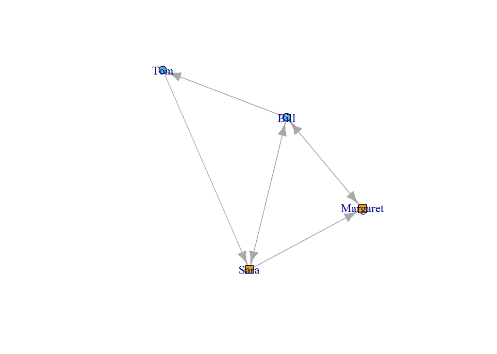

```r
plot(gg, edge.label = NA, vertex.color = factor(V(gg)$gender),
     vertex.shape = V(gg)$shape, layout = gg_layout, vertex.size=8)
```

## Name ties based on types

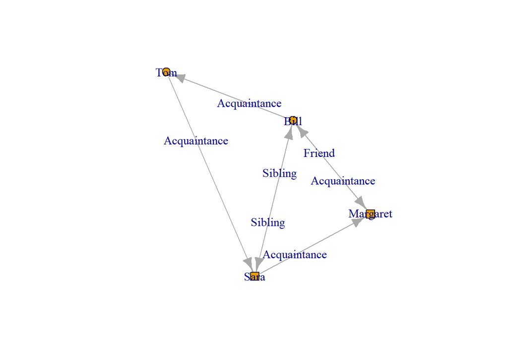

```r
plot(gg, edge.label = E(gg)$label, layout = gg_layout, vertex.size=8)
```

## Weight ties based on importance

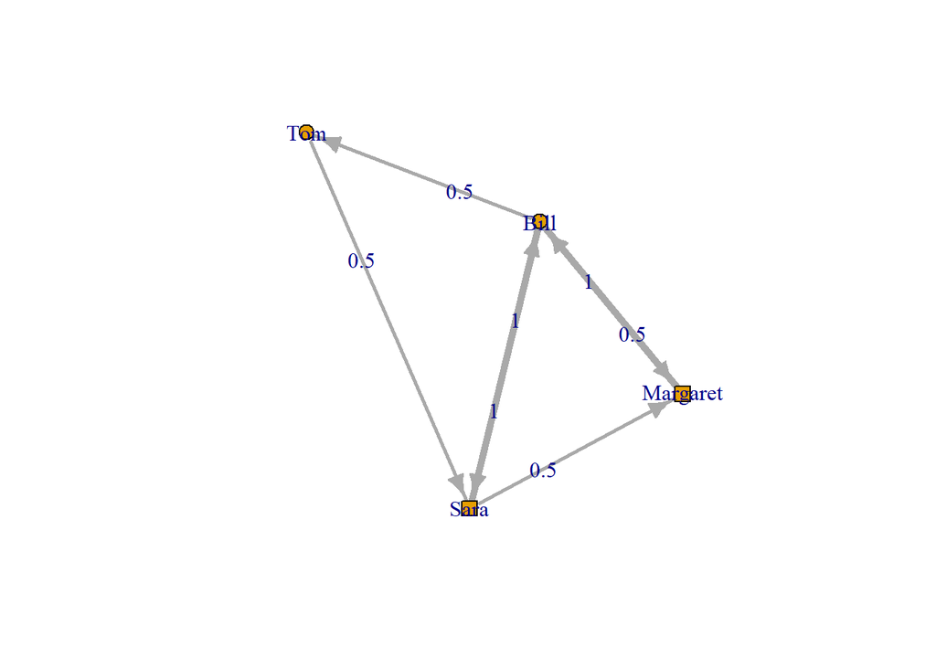

```r
plot(gg, edge.width = E(gg)$weight*5, edge.label = E(gg)$weight, layout = gg_layout, vertex.size=8)
```

## Mixture of weight/label

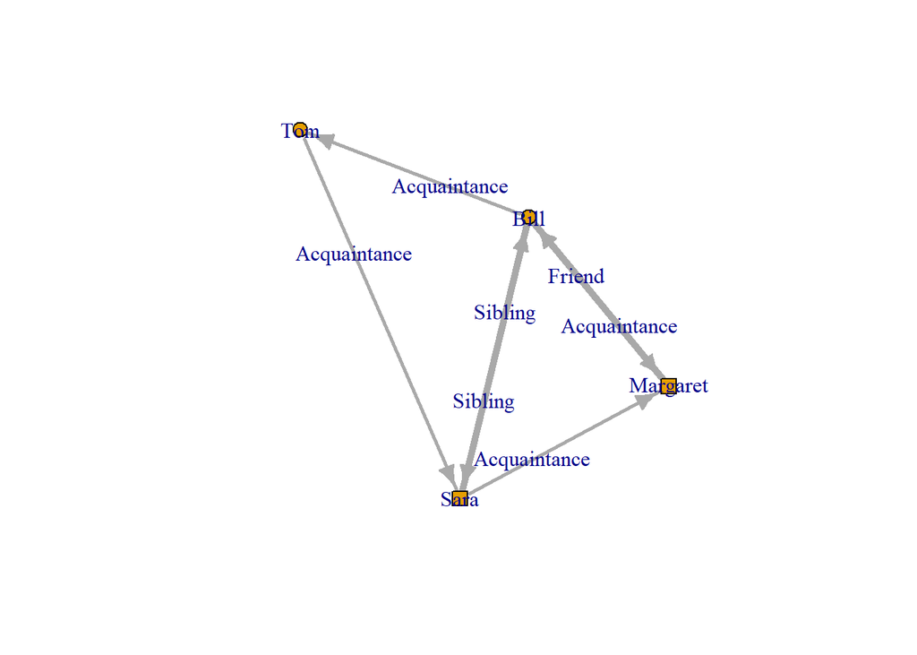

```r
plot(gg, edge.label = E(gg)$label, edge.width = E(gg)$weight*5, layout = gg_layout, vertex.size=8)
```

## A glimpse to more serious analysis

- After simple visualization (if possible), a five number summary!
  1. **Size**: *V*, *E* (N of vertices/nodes and ties/edges, respectively)
  2. **Density** (ratio of ties to possible ties, 1 = fully connected)
  3. **Components** & (dis)connectivity (more connection inside groups, less among them)
  4. **Diameter** (how compact the network is?)
  5. **Clustering Coefficient** (transitivity and triangles)
- **Centrality** in network (different measures of importance in structure)
  - Degree, Closeness, Betweenness, Eigenvector, …

## In-degree of a node (incoming ties)

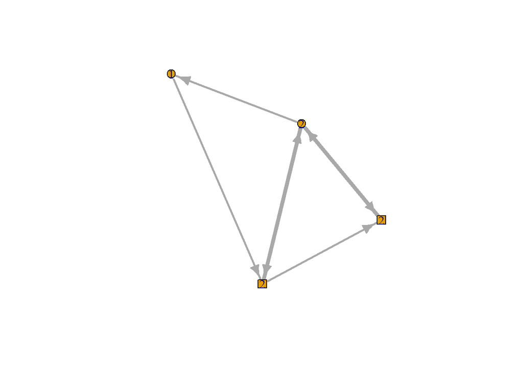

```r
plot(gg, edge.label = NA, edge.width = E(gg)$weight*5,
     vertex.label = degree(gg, mode = 'in'), layout = gg_layout, vertex.size=8)
```

## Out-degree of a node (outgoing ties)

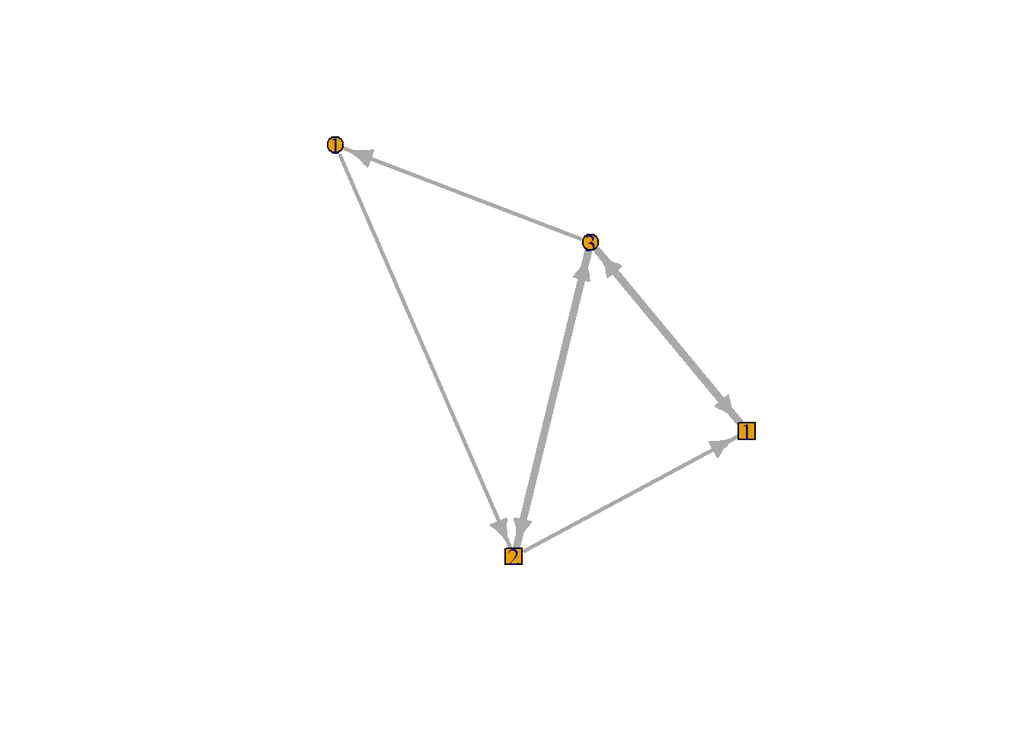

```r
plot(gg, edge.label = NA, edge.width = E(gg)$weight*5,
     vertex.label = degree(gg, mode = 'out'), layout = gg_layout, vertex.size=8)
```

## Degree of a node (both incoming/outgoing ties)

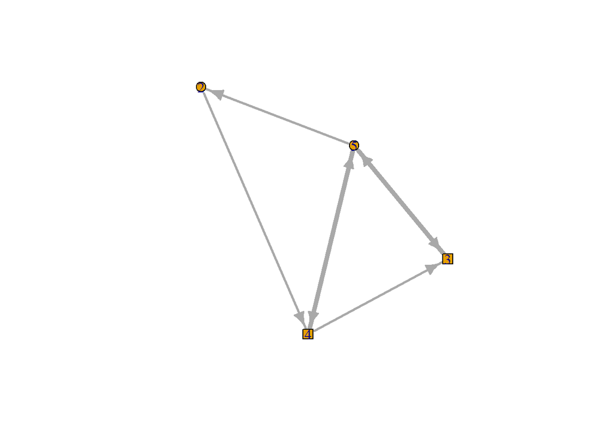

```r
plot(gg, edge.label = NA, edge.width = E(gg)$weight*5,
     vertex.label = degree(gg, mode = 'all'), layout = gg_layout, vertex.size=8)
```

# Conditional Uniform Graph Tests (CUG)

The idea is straightforward, we take the network statistic that we have observed in our empirical network and compare it with randomly generated network which is conditioned based on density, count of edges and nodes to be as similar as possible to our empirical network.

The goal is to answer, does the empirical network have properties that we would expect to see randomly i.e., in a random network or not.

SNA package provides methods todo such test and plot the results.

Please note that if we do not set a random seed, we will get different random networks and the test results will be stochastically changing.

```r
# from SNA R library documentation and methods
library(sna)
```

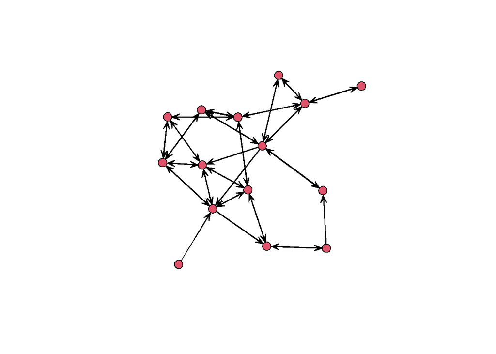

```r
# set a seed to obtain the same results
set.seed(124)

# Draw a highly reciprocal network
g<-rguman(1,15,mut=0.25,asym=0.05,null=0.7)

# a look
sna::gplot(g)
```

```r
#Test transitivity against size, density, and the dyad census
cug.test(g,gtrans,cmode="size")
```

```
##
## Univariate Conditional Uniform Graph Test
##
## Conditioning Method: size
## Graph Type: digraph
## Diagonal Used: FALSE
## Replications: 1000
##
## Observed Value: 0.2396694
## Pr(X>=Obs): 1
## Pr(X<=Obs): 0
```

```r
cug.test(g,gtrans,cmode="edges")
```

```
##
## Univariate Conditional Uniform Graph Test
##
## Conditioning Method: edges
## Graph Type: digraph
## Diagonal Used: FALSE
## Replications: 1000
##
## Observed Value: 0.2396694
## Pr(X>=Obs): 0.181
## Pr(X<=Obs): 0.821
```

```r
cug.test(g,gtrans,cmode="dyad.census")
```

```
##
## Univariate Conditional Uniform Graph Test
##
## Conditioning Method: dyad.census
## Graph Type: digraph
## Diagonal Used: FALSE
## Replications: 1000
##
## Observed Value: 0.2396694
## Pr(X>=Obs): 0.297
## Pr(X<=Obs): 0.705
```

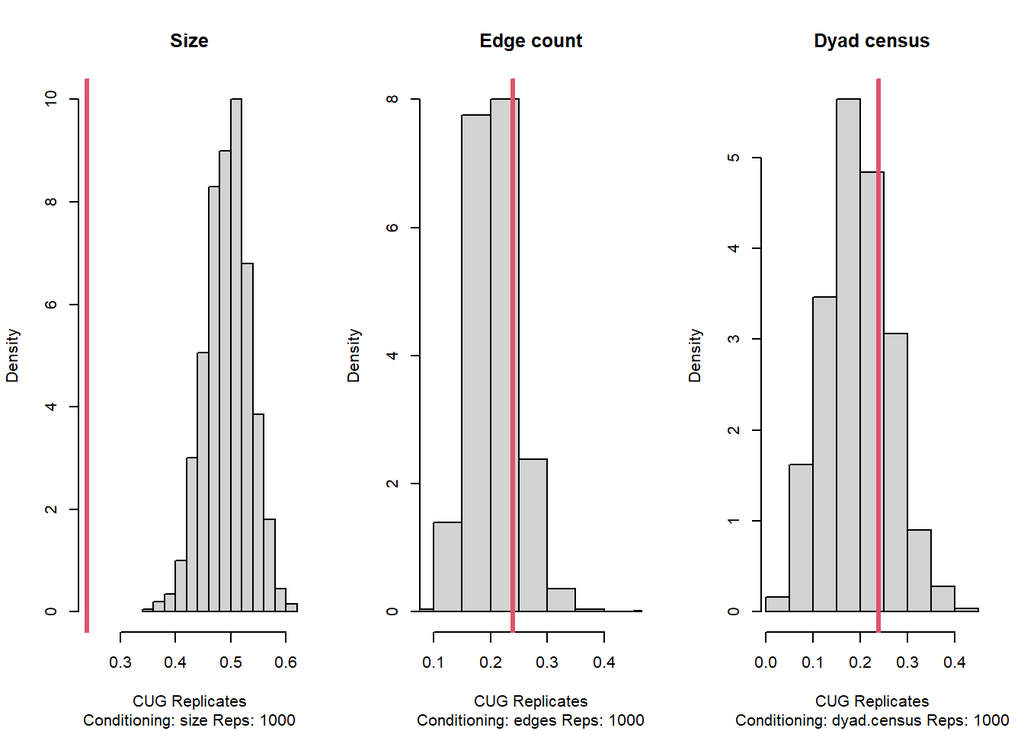

```r
# plot them
par(mfrow=c(1,3))
plot(cug.test(g,gtrans,cmode="size"), main='Size')

plot(cug.test(g,gtrans,cmode="edges"), main='Edge count')

plot(cug.test(g,gtrans,cmode="dyad.census"), main='Dyad census')
```

See here for more elaborate examples or check the books and papers I introduced on slides: https://rpubs.com/pjmurphy/536741

# Example of a bibliometric network

## Bipartite network with paper and author nodes, and visualization

Here is the bible of iGraph visualization: https://kateto.net/network-visualization

My method in getting a replicable visualization with fixed layout: https://akbaritabar.github.io/CV_MD/replicable_network_vis.html

```r
# read edges
edges_table <- read_csv('../data/bipartite_author_paper_edges.csv')
# a look
head(edges_table)
```

```
## # A tibble: 6 × 4
##   source      target     row_num  year
##   <chr>       <chr>        <dbl> <dbl>
## 1 author_1717 paper_1121       6  2000
## 2 author_7315 paper_1121       7  2000
## 3 author_1714 paper_1121       8  2000
## 4 author_1716 paper_1121       9  2000
## 5 author_1715 paper_1121      11  2000
## 6 author_1891 paper_1260      23  2001
```

```r
# read vertices
vertices_table <- read_csv('../data/bipartite_author_paper_vertices.csv')
# a look
head(vertices_table)
```

```
## # A tibble: 6 × 6
##   vertex_id   row_num type  type2  shape  gender
##   <chr>         <dbl> <lgl> <chr>  <chr>  <chr>
## 1 author_1714       1 TRUE  author square male
## 2 author_1716       2 TRUE  author square male
## 3 author_1891       3 TRUE  author square male
## 4 author_2024       4 TRUE  author square male
## 5 author_2025       5 TRUE  author square male
## 6 author_2288       6 TRUE  author square male
```

```r
# create a network
bip_author_paper <- graph_from_data_frame(d = edges_table, vertices = vertices_table, directed = FALSE)

# this writes a summary of graph object, attributes, etc.
print(bip_author_paper)
```

```
## IGRAPH 196b4aa UN-B 45 46 --
## + attr: name (v/c), row_num (v/n), type (v/l), type2 (v/c), shape
## | (v/c), gender (v/c), row_num (e/n), year (e/n)
## + edges from 196b4aa (vertex names):
##  [1] author_1717--paper_1121 author_7315--paper_1121 author_1714--paper_1121
##  [4] author_1716--paper_1121 author_1715--paper_1121 author_1891--paper_1260
##  [7] author_7323--paper_1260 author_1890--paper_1260 author_1892--paper_1260
## [10] author_3889--paper_1260 author_6506--paper_1368 author_2025--paper_1368
## [13] author_2024--paper_1368 author_6903--paper_1368 author_6905--paper_1368
## [16] author_3889--paper_1368 author_3889--paper_1541 author_1715--paper_1541
## [19] author_2288--paper_1553 author_2290--paper_1553 author_6511--paper_1553
## + ... omitted several edges
```

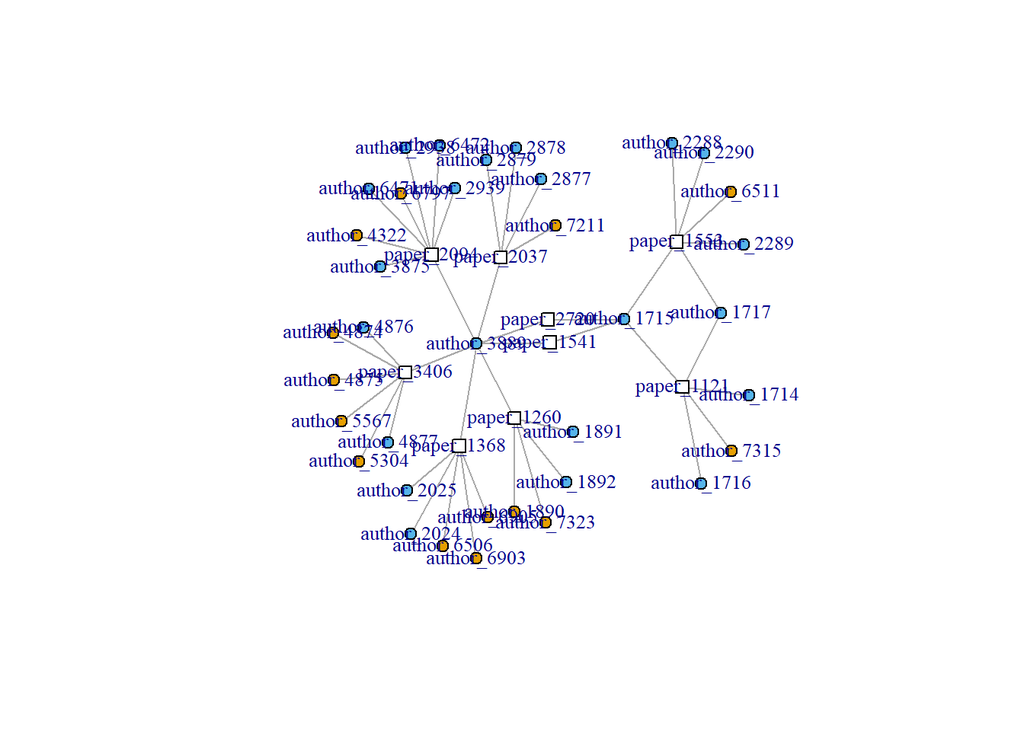

```r
bip_author_paper_layout = layout.kamada.kawai(graph = bip_author_paper)

# add shape/color based on type of bipartite nodes
V(bip_author_paper)$shape <- c("square", "circle")[V(bip_author_paper)$type+1]

# visualize it (see Kateo's bible for elements to modify)
plot(bip_author_paper, layout = bip_author_paper_layout, edge.label = NA, vertex.size=6, vertex.label.cex=0.8, vertex.color = factor(V(bip_author_paper)$gender))
```

## Projection to one mode

```r
both_graphs <- bipartite_projection(bip_author_paper)

print(both_graphs)
```

```
## $proj1
## IGRAPH 19d9a22 UNW- 9 26 --
## + attr: name (v/c), row_num (v/n), type2 (v/c), shape (v/c), gender
## | (v/c), weight (e/n)
## + edges from 19d9a22 (vertex names):
##  [1] paper_1121--paper_1553 paper_1121--paper_1541 paper_1121--paper_2720
##  [4] paper_1260--paper_1368 paper_1260--paper_1541 paper_1260--paper_2037
##  [7] paper_1260--paper_2094 paper_1260--paper_2720 paper_1260--paper_3406
## [10] paper_1368--paper_1541 paper_1368--paper_2037 paper_1368--paper_2094
## [13] paper_1368--paper_2720 paper_1368--paper_3406 paper_1541--paper_1553
## [16] paper_1541--paper_2720 paper_1541--paper_2037 paper_1541--paper_2094
## [19] paper_1541--paper_3406 paper_1553--paper_2720 paper_2037--paper_2094
## + ... omitted several edges
##
## $proj2
## IGRAPH 19d9a97 UNW- 36 109 --
## + attr: name (v/c), row_num (v/n), type2 (v/c), shape (v/c), gender
## | (v/c), weight (e/n)
## + edges from 19d9a97 (vertex names):
##  [1] author_1714--author_1716 author_1714--author_1717 author_1714--author_1715
##  [4] author_1714--author_7315 author_1716--author_1717 author_1716--author_1715
##  [7] author_1716--author_7315 author_1891--author_1892 author_1891--author_3889
## [10] author_1891--author_1890 author_1891--author_7323 author_2024--author_2025
## [13] author_2024--author_3889 author_2024--author_6506 author_2024--author_6903
## [16] author_2024--author_6905 author_2025--author_3889 author_2025--author_6506
## [19] author_2025--author_6903 author_2025--author_6905 author_2288--author_2289
## + ... omitted several edges
```

```r
papers_g <- both_graphs$proj1

authors_g <- both_graphs$proj2
```

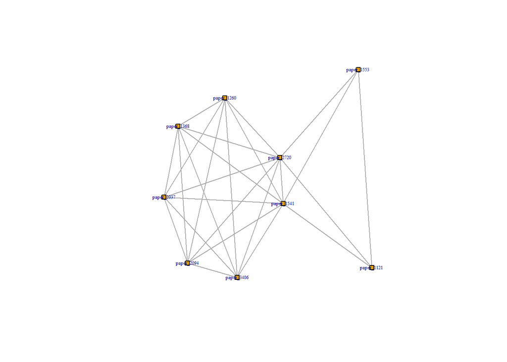

```r
# visualize it (see Kateo's bible for elements to modify)
plot(papers_g, layout = layout.kamada.kawai, edge.label = NA, vertex.size=4, vertex.label.cex=0.4)
```

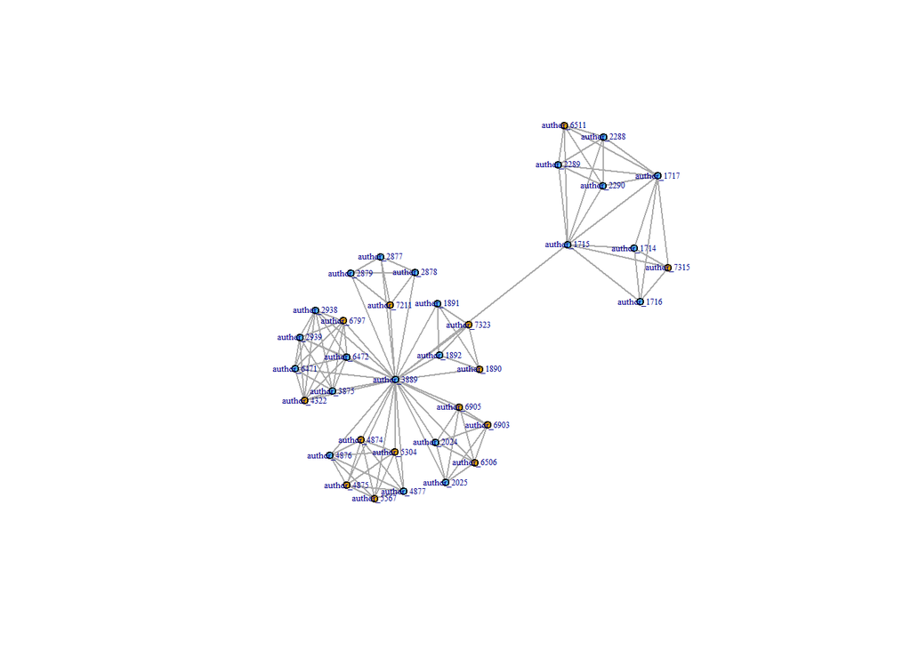

```r
plot(authors_g, layout = layout.kamada.kawai, edge.label = NA, vertex.size=4, vertex.label.cex=0.4, vertex.color = factor(V(bip_author_paper)$gender))
```

# Exponential Random Graph Models (ERGMs) using Statnet and Ergm

Please check also the official ERGM tutorial on statnet page: https://statnet.org/workshop-ergm/ergm_tutorial.html

Here we will continue using our toy example.

First, we need to either read the graph from edgelist with statnet, or use “intergraph” to convert igraph object to network object (see here: https://cran.r-project.org/web/packages/intergraph/vignettes/howto.html).

```r
library(intergraph)

authors_g_n <- asNetwork(authors_g)

print(authors_g)
```

```
## IGRAPH 19d9a97 UNW- 36 109 --
## + attr: name (v/c), row_num (v/n), type2 (v/c), shape (v/c), gender
## | (v/c), weight (e/n)
## + edges from 19d9a97 (vertex names):
##  [1] author_1714--author_1716 author_1714--author_1717 author_1714--author_1715
##  [4] author_1714--author_7315 author_1716--author_1717 author_1716--author_1715
##  [7] author_1716--author_7315 author_1891--author_1892 author_1891--author_3889
## [10] author_1891--author_1890 author_1891--author_7323 author_2024--author_2025
## [13] author_2024--author_3889 author_2024--author_6506 author_2024--author_6903
## [16] author_2024--author_6905 author_2025--author_3889 author_2025--author_6506
## [19] author_2025--author_6903 author_2025--author_6905 author_2288--author_2289
## + ... omitted several edges
```

```r
print(authors_g_n)
```

```
##  Network attributes:
##   vertices = 36
##   directed = FALSE
##   hyper = FALSE
##   loops = FALSE
##   multiple = FALSE
##   bipartite = FALSE
##   total edges= 109
##     missing edges= 0
##     non-missing edges= 109
##
##  Vertex attribute names:
##     gender row_num shape type2 vertex.names
##
##  Edge attribute names:
##     weight
```

```r
# check class
class(authors_g_n)
```

```
## [1] "network"
```

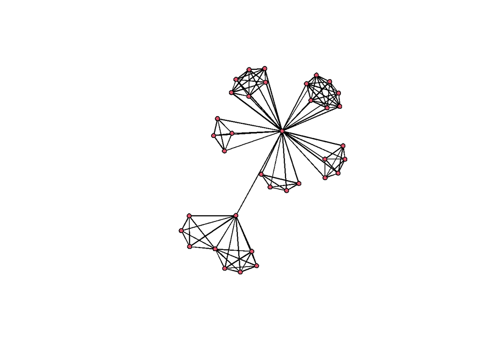

```r
# similar to igraph, you can plot and do all sorts of things using this network object
plot(authors_g_n, vertex.cex = 1)
```

```r
library(statnet)
# or library(ergm) if you only use ergm function

# simplest model
m_only_edges <- ergm(authors_g_n ~ edges)
```

```
## Starting maximum pseudolikelihood estimation (MPLE):
```

```
## Obtaining the responsible dyads.
```

```
## Evaluating the predictor and response matrix.
```

```
## Maximizing the pseudolikelihood.
```

```
## Finished MPLE.
```

```
## Evaluating log-likelihood at the estimate.
```

```r
summary(m_only_edges)
```

```
## Call:
## ergm(formula = authors_g_n ~ edges)
##
## Maximum Likelihood Results:
##
##       Estimate Std. Error MCMC % z value Pr(>|z|)
## edges  -1.5644     0.1053      0  -14.85   <1e-04 ***
## ---
## Signif. codes:  0 '***' 0.001 '**' 0.01 '*' 0.05 '.' 0.1 ' ' 1
##
##      Null Deviance: 873.4  on 630  degrees of freedom
##  Residual Deviance: 580.4  on 629  degrees of freedom
##
## AIC: 582.4  BIC: 586.8  (Smaller is better. MC Std. Err. = 0)
```

```r
library(texreg)
screenreg(m_only_edges)
```

```
##
## ===========================
##                 Model 1
## ---------------------------
## edges             -1.56 ***
##                   (0.11)
## ---------------------------
## AIC              582.40
## BIC              586.85
## Log Likelihood  -290.20
## ===========================
## *** p < 0.001; ** p < 0.01; * p < 0.05
```

## A comprehenstive list of ERGM terms and cross-referencing them

See here for the list of available ERGM terms and for which networks (directed, undirected, bipartite, etc) you can use them.

https://cran.r-project.org/web/packages/ergm/vignettes/ergm-term-crossRef.html

```r
# a bit more complicated model with homophily based on gender
m_gender <- ergm(authors_g_n ~ edges + nodematch("gender", diff=T))
```

```
## Starting maximum pseudolikelihood estimation (MPLE):
```

```
## Obtaining the responsible dyads.
```

```
## Evaluating the predictor and response matrix.
```

```
## Maximizing the pseudolikelihood.
```

```
## Finished MPLE.
```

```
## Evaluating log-likelihood at the estimate.
```

```r
summary(m_gender)
```

```
## Call:
## ergm(formula = authors_g_n ~ edges + nodematch("gender", diff = T))
##
## Maximum Likelihood Results:
##
##                         Estimate Std. Error MCMC % z value Pr(>|z|)
## edges                    -1.5939     0.1521      0 -10.479   <1e-04 ***
## nodematch.gender.female  -0.3902     0.3557      0  -1.097    0.273
## nodematch.gender.male     0.2022     0.2242      0   0.902    0.367
## ---
## Signif. codes:  0 '***' 0.001 '**' 0.01 '*' 0.05 '.' 0.1 ' ' 1
##
##      Null Deviance: 873.4  on 630  degrees of freedom
##  Residual Deviance: 577.4  on 627  degrees of freedom
##
## AIC: 583.4  BIC: 596.7  (Smaller is better. MC Std. Err. = 0)
```

```r
screenreg(list(m_only_edges, m_gender))
```

```
##
## =================================================
##                          Model 1      Model 2
## -------------------------------------------------
## edges                      -1.56 ***    -1.59 ***
##                            (0.11)       (0.15)
## nodematch.gender.female                 -0.39
##                                         (0.36)
## nodematch.gender.male                    0.20
##                                         (0.22)
## -------------------------------------------------
## AIC                       582.40       583.41
## BIC                       586.85       596.75
## Log Likelihood           -290.20      -288.71
## =================================================
## *** p < 0.001; ** p < 0.01; * p < 0.05
```

Good luck from here and best wishes for analyzing networks!

[^1]: Python users, check scripts “09_example_network_igraph_python.py” and “10_igraph_from_pandas.py” in notebooks directory under “for_python_users”